# P&S-2025 Lab assignment 2

### Task 4.

**This task consists of two parts:**

1. **In this part, we discuss independence of random variables and its moments: expectation and variance.**
   1. Suppose we have a random variable $X$. Explain why $\mathbb{E}(\frac{1}{X}) \neq \frac{1}{\mathbb{E(X)}}$;

   **Explanation**

   For the explanation let’s use Jensen’s inequality. It states that if $f$ is a convex function and $X$ is a random variable, then $f(\mathbb{E}[X]) \leq \mathbb{E}[f(X)]$. For $f(x) = \frac{1}{x}$ (defined for $x>0$): $f'(x) = -\frac{1}{x^2}, \qquad f''(x) = \frac{2}{x^3} > 0$

   Hence, $f$ is convex on $(0, \infty)$.

   Applying Jensen’s inequality: $\frac{1}{\mathbb{E}[X]} = f(\mathbb{E}[X]) \leq \mathbb{E}[f(X)] = \mathbb{E}\!\left[\frac{1}{X}\right]$.

   Same applies to $x<0$ ($f′′(x)<0$ - function is concave) but the inequality will be reversed: $\frac{1}{\mathbb{E}[X]} \geq \mathbb{E}\!\left[\frac{1}{X}\right]$.
   2. Let $X \sim \mathscr{N}(\mu,\sigma^2)$ with $\mu = teamidnumber$ and $\sigma^{2} = 2\times teamidnumber+7$. Simulate realizations $x_1,x_2,\dots,x_{100}$ of $X$ and $y_1,y_2,\dots,y_{100}$ of $Y := \frac{1}{X}$ to calculate the values of $\frac{1}{\overline{\textbf{X}}}$ and $\overline{\textbf{Y}}$. Comment on the received results;

   ```r
   mu <- 35
   sigma <- 77
   N <- 100
   stadd <- sqrt(sigma)

   x <- rnorm(N, mean=mu, sd=stadd)
   mean_x <- mean(x)
   one_over_mean_x <- 1 / mean_x

   y <- 1 / x
   mean_y <- mean(y)

   cat("1/E(X) =", one_over_mean_x, "\n")
   ```

   ```
   ## 1/E(X) = 0.02837159
   ```

   ```r
   cat("E(1/X) =", mean_y, "\n")
   ```

   ```
   ## E(1/X) = 0.03101446
   ```

   ```r
   # The output proves the inequality above.
   ```

   3. Let $X$ and $Y$ be exponentially distributed r.v.’s with parameter $\lambda = 2$. Set $Z := \log{X} + 5$. Plot the Quantile-Quantile plot and scatterplot of $X$ and $Y$. Plot the Quantile-Quantile plot and scatterplot of $X$ and $Z$. Explain the results. Comment on the difference of relations between the pairs of random variables. Which pair of r.v.’s is dependent and which one is similar?

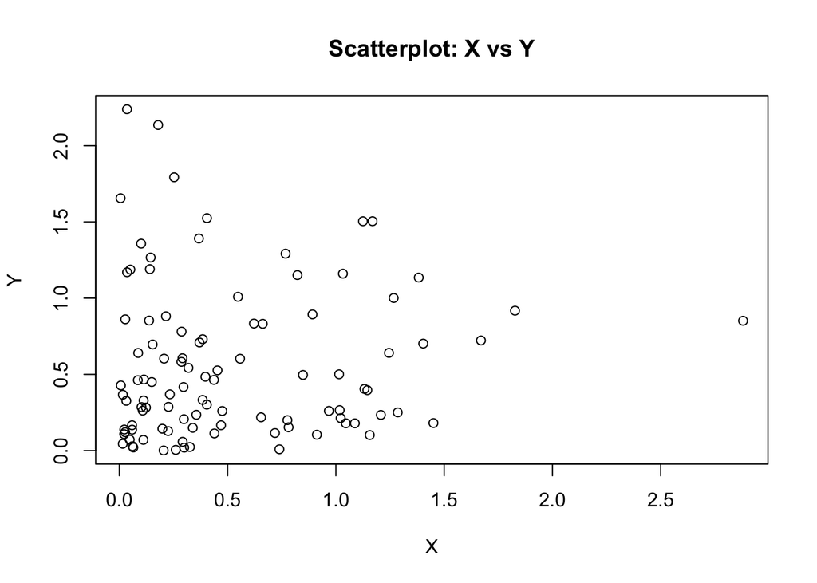

```r
X <- rexp(N, rate=2)
Y <- rexp(N, rate=2)
Z <- log(X) + 5

plot(X, Y, main="Scatterplot: X vs Y")
```

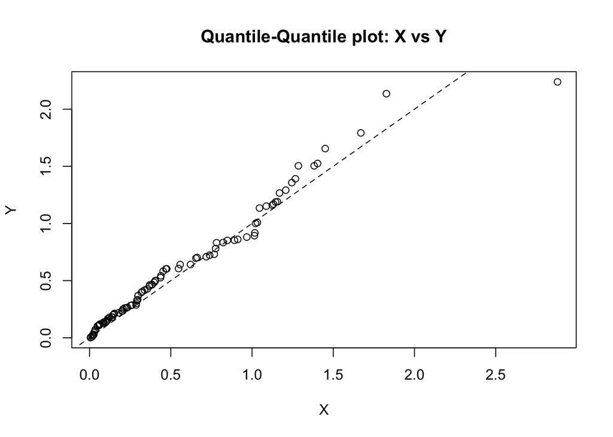

```r
# There is a cloud-like image and no pattern on the plot. That proves that r. v. X and Y are independent.
qqplot(X, Y, main="Quantile-Quantile plot: X vs Y"); abline(0, 1, lty=2)
```

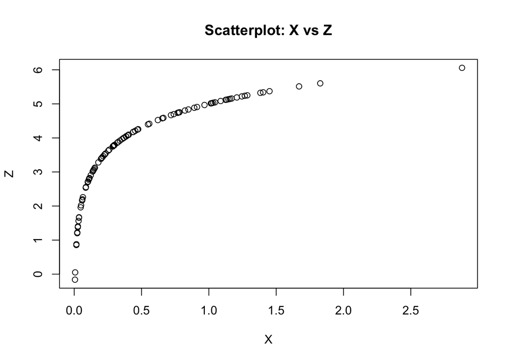

```r
# Points are clustered near the line meaning that X and Y have similar distribution (some "rogue" points appear because of noise).
# So we conclude that X and Y are independent and similar.

plot(X, Z, main="Scatterplot: X vs Z")
```

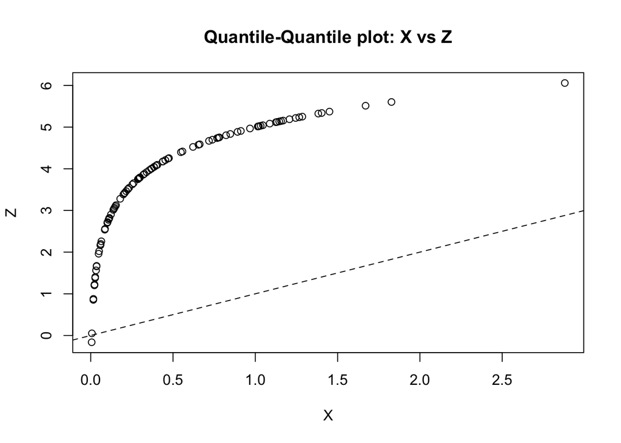

```r
# Points follow a strict pattern that reminds the graph of logarithm. And indeed Z is log(X)+5, exactly what we see on the plot. So, X and Z are dependent (Z is a function of X).
qqplot(X, Z, main="Quantile-Quantile plot: X vs Z"); abline(0, 1, lty=2)
```

```r
# QQ-plot is also log-shaped signifying that the distribution of X and Z don't match (otherwise, we would see points lying on the diagonal as in case with X and Y). So X and Z are not similar.
# X and Z are dependent but not similar.
```

2. You toss a fair coin three times and a random variable $X$ records how many times the coin shows Heads. You convince your friend that they should play a game with the following payoff: every round (equivalent to three coin tosses) will cost £$1$. They will receive £$0.5$ for every coin showing Heads. What is the expected value and the variance of the random variable $Y := 0.5X-1$?

   To answer this,
   1. Explain what type of random variable is X:
      - Normally distributed
      - Binomially distributed
      - Poisson distributed
      - Uniformly distributed

      **Explanation**

      $X$ is binomially distributed value with parameters $n = 3$ (number of times we toss a coin) and $p = 0.5$ (probability to get a Head).
   2. What are the expected value and variance of X? Simulate realizations $x_1,x_2,\dots,x_{100}$ of $X$ to calculate the values of sample mean $\overline{\mathbf{X}}$ and sample variance $s^2 = \frac{\sum_{i=1}^{n}{(x_i - \overline{x})^{2}}}{n-1}$. Comment on the results;

   ```r
   N <- 100
   X <- rbinom(N, size = 3, prob = 0.5)

   sample_mean_X <- mean(X)
   sample_var_X <- var(X)     # uses n-1 in denominator, had to look for R documentation for that

   # Let's also calculate theoretical mean and theoretical variance and compare them to the those we got via simulation
   theoretical_mean_X <- 3 * 0.5
   theoretical_var_X <- 3* 0.5 * (1- 0.5)

   cat("sample mean:", sample_mean_X, "\n")
   ```

   ```
   ## sample mean: 1.44
   ```

   ```r
   cat("sample variance:", sample_var_X, "\n")
   ```

   ```
   ## sample variance: 0.6933333
   ```

   ```r
   cat("theoretical mean:", theoretical_mean_X, "\n")
   ```

   ```
   ## theoretical mean: 1.5
   ```

   ```r
   cat("theoretical variance:", theoretical_var_X, "\n\n")
   ```

   ```
   ## theoretical variance: 0.75
   ```

   ```r
   print("We see that sample mean and sample variance are indeed close to their theoretical counterparts.")
   ```

   ```
   ## [1] "We see that sample mean and sample variance are indeed close to their theoretical counterparts."
   ```

   3. What are the expected value and variance of Y? Simulate realizations $y_1,y_2,\dots,y_{100}$ of $Y$ to calculate the values of sample mean $\overline{\mathbf{Y}}$ and sample variance $s^2 = \frac{\sum_{i=1}^{n}{(y_i - \overline{y})^{2}}}{n-1}$. Comment on the results;

   ```r
   Y <- 0.5 * X - 1

   sample_mean_Y <- mean(Y)
   sample_var_Y <- var(Y)     # uses n-1 in denominator, had to look for R documentation for that

   # Again, let's calculate theoretical mean and theoretical variance and compare them to the those we got via simulation
   theoretical_mean_Y <- 0.5 * theoretical_mean_X - 1
   theoretical_var_Y <- (0.5)^2 * theoretical_var_X

   cat("sample mean:", sample_mean_Y, "\n")
   ```

   ```
   ## sample mean: -0.28
   ```

   ```r
   cat("sample variance:", sample_var_Y, "\n")
   ```

   ```
   ## sample variance: 0.1733333
   ```

   ```r
   cat("theoretical mean:", theoretical_mean_Y, "\n")
   ```

   ```
   ## theoretical mean: -0.25
   ```

   ```r
   cat("theoretical variance:", theoretical_var_Y, "\n\n")
   ```

   ```
   ## theoretical variance: 0.1875
   ```

   ```r
   print("So again, we see that sample mean and sample variance are indeed close to their theoretical counterparts.In addition, after finding both theoretical and sample variance of Y, we see that it is not a goog idea to play this game, as on average, the player will lose money.")
   ```

   ```
   ## [1] "So again, we see that sample mean and sample variance are indeed close to their theoretical counterparts.In addition, after finding both theoretical and sample variance of Y, we see that it is not a goog idea to play this game, as on average, the player will lose money."
   ```

What we have done in task 4:

Part 1:

- We used Jensen’s inequality to prove that $\mathbb{E}(\frac{1}{X}) \neq \frac{1}{\mathbb{E(X)}}$. This theoretical conclusion was further supported by practical proof via simulation.
- We examined dependence and similarity between random variables. After plotting scatterplot and QQ-plot for X and Y we concluded that they were independent and similar. After doing the same for X and Z, we concluded that they were dependent but not similar.

Part 2:

- We looked at the example of a game with coin. We concluded that r.v. $X\mathtt{\sim} Binomial(n=3, p=0.5)$
- We found sample mean and variance for both X and Y. They both were close to theoretical mean and variance which demonstrated that the theory we learn at this course works in practice, and that was really nice to observe.
- In addition, we concluded that the player of this game on average gets negative payoff, so it is better not to play it and avoid friends who want to get you to do so.

### General summary and conclusions

**Task 1 - Hamming [7,4].** We encoded random 4-bit messages, sent 7-bit codewords through a noisy channel with bit-flip rate $id/100$ , corrected with the H, and measured how often decoding succeeded. The simulation success rate $\hat p$ estimates the true success p* and agrees with the idea that averaging many trials reveals the real reliability (LLN/CLT). We also used the known formula “0 or 1 error among 7 bits” for a theory check and reported a 95% CI. To keep the $\epsilon$ ≤0.03, about N≈1068 trials are enough. Finally, the histogram of errors for a raw 4-bit message matches a Binomial(4,p) law.

**Task 2 - CLT with count data (radioactivity).** We modeled radioactive decays with Poisson variables, looked at averages over many samples, and showed the empirical CDF of sample means is almost the same as a Normal CDF - so the Central Limit Theorem works well here. We also computed how large a sample is needed to reach a target probability and verified it by simulation.

**Task 3 - CLT for continuous variables.** We repeated the CLT idea for continuous distributions: approximate the distribution of sums/averages by Normal, choose n from the CLT (and cross-check with bounds like Chernoff), and confirm by simulation.

**Task 4 - Overall takeaways.** Across tasks we combined simulation and theory: we used coding theory facts (syndrome decoding for Hamming), binomial/Poisson models, confidence intervals from the normal approximation, and classic limit theorems (LLN/CLT), and we checked results visually with plots and numerically with probability bounds and sample-size formulas.